# Objective Two — Vector-Informed Epiwave FOI Model (Methods & Framing)

Ernest Moyo

2026-03-05

# 1 Introduction

# 2 Methods

## 2.1 Model

This implements the supervisor’s recommended two-stage approach:

- **Two-stage approach:** (1) Use **fixed** $m,a,g$ from Vector Atlas to solve Ross-MacDonald ODEs **once per pixel**, generating mechanistic FOI predictions $I^{\ast}_{s,t}$; (2) Model observed case counts as $C_{s,t} \sim \text{NegBin}(\text{size}, p)$ with $\log(\mu_{s,t}) = \lambda + \log(I^{\ast}_{s,t})$, where $\lambda$ is the log reporting rate and the NegBin overdispersion captures residual variation.
- **Key advantage:** No inference on ODE parameters — avoids computational bottleneck while leveraging mechanistic knowledge.

### 2.1.1 REQUIRED APPROACH (Supervisor Specification - Verbatim Implementation)

The code implements the following supervisor guidance:

> “Don’t do statistical inference on the dynamic part of the model. Instead, use fixed values for the entomological parameters over space and time (VA estimates or temperature-dependent relationships) and then for each pixel, solve the dynamics once to get an a priori prediction of mosquito prevalence z_{t}. Then compute the a priori, mechanistically predicted human infection incidence for each pixel, I*_{t}:

> I*{t} = m*{t} a_{t} * b_{t} * z_{t}

> Then, in epiwave.mapping, model the infection incidence in space and time, I_{s,t}, as:

> I_{s,t} = exp( a + ln( I**{s,t}) + e*{s,t} )

> where a is an intercept term and e_{s,t} are spatio-temporal random effects with a zero-mean stationary Gaussian process prior.”

**How this is implemented:** - ✅ **No inference on m, a, g**: All entomological parameters are fixed inputs - ✅ **ODE solve ONCE per pixel**: solve_ross_macdonald_multi_site() solves ODEs once, not during MCMC - ✅ **Mechanistic prediction I***: compute_mechanistic_prediction() implements I* = m × a × b × z - ✅ **Offset model**: fit_epiwave_with_offset() constructs log(μ) = λ + log(I*) - ✅ **Residual structure**: NegBin overdispersion absorbs residual variation (GP abandoned after v1-v3 failures; see Stage 2 Evolution) - ✅ **Intervention effects**: apply_interventions() modifies m, a, g parameters before ODE solving - **Simulation estimation study** -* (We are already doing this ad‑hoc.)* - Goal: **How well can you recover the parameters** and FOI/incidence when data are simulated from known $m(t,s),a(t,s),g(t,s)$ and interventions. - **Case study** - **Tanzania**; **low‑response/simple** setup, focusing on interventions and publicly available MAP layers (e.g., **ITNs**, IRS) — **as simple as possible, as complicated as necessary** to illustrate the workflow.

## 2.2 Model Description

### 2.2.1 Data types (what the model can use)

- **Observation data (response):** monthly **cases** ($C$) and optional **prevalence** clusters ($Y,N$).
- **Vector / entomology (drivers of VD):** abundance/proxy layers, micro‑climate–derived survival, bioassay **resistance** indices, ITN/IRS **coverage/use**.
- **Environment:** rainfall, temperature, humidity, NDVI, elevation (harmonised to grid/time).

### 2.2.2 Observation models (same as EpiWave; brief recap)

- **Cases (admin unit** $l$, month $t$):
  $$C_{l,t}\sim \mathrm{Poisson}\!\big(\gamma_l I_{l,t}\big),\quad
  \gamma_l>0\ \text{(reporting/symptomatic rate; optionally
  hierarchical)}.$$
  Pixel‑to‑admin aggregation via population weights; $I_{l,t}$ is **latent incidence** linked below.
- **Prevalence (optional):**
  $$Y_{l,t}\sim \mathrm{Binomial}\!\big(N_{l,t}, p_{l,t}\big),\qquad
  p_{l,t}\ \text{linked to latent incidence or auxiliary state.}$$

> **Connector (mindful of notation):** we define the **force of infection** $\xi_{t,s}$ (per‑person per‑day) from the transmission block below, and use standard EpiWave mappings to connect $\xi$ → **incidence** $I$ → **cases** $C$ (and optionally to **prevalence** $p$) without altering the observation likelihoods.

### 2.2.3 Transmission block (Ross–Macdonald + FOI; VD elevated)

We use a two‑compartment vector–host kernel with **time‑ and space‑varying** vector processes:
$$\frac{dx_{t,s}}{dt}= m_{t,s}\,a_{t,s}\,b\,z_{t,s}\,(1-x_{t,s})-
r\,x_{t,s},\qquad
\frac{dz_{t,s}}{dt}= a_{t,s}\,c\,x_{t,s}\,(1-z_{t,s})- g_{t,s}\,z_{t,s},$$
with **FOI**
$$\xi_{t,s} \equiv m_{t,s}\,a_{t,s}\,b\,z_{t,s}.$$
We hold $b,c,r$ constant in v1; novelty concentrates on $m_{t,s}, a_{t,s}, g_{t,s}$.

#### 2.2.3.1 Supports (parameter domains)

$$m_{t,s}>0,\qquad a_{t,s}\in(0,1]\ \text{(first‑bite
convention)},\qquad g_{t,s}>0.$$

### 2.2.4 Covariate‑linked vector processes

#### 2.2.4.1 Mosquito abundance $m_{t,s}$

Baseline $m^{\ast}_{t,s}$ (e.g., Vector‑Atlas/HLC‑proportional outputs) scaled by covariates and interventions:
$$m_{t,s} \;=\; m^{\ast}_{t,s}\,\exp\!\big(X^{(m)}_{t,s}\,\beta_m\big)\,
\underbrace{\Big[(1-n_{t,s}) +
n_{t,s}\,(1-\pi^{(m)}_{t,s})\Big]}_{\text{ITN population‑reduction
factor}},$$
where $n_{t,s}\in[0,1]$ is net use/coverage and $\pi^{(m)}_{t,s}\in[0,1]$ is the **fractional reduction among net‑encountering mosquitoes**; resistance modifies effectiveness via susceptibility $u_{t,s}$:
$$\pi^{(m)}_{t,s} = u_{t,s}\,\pi^{(m)}_{0},\qquad u_{t,s}\in[0,1].$$

#### 2.2.4.2 Biting rate $a_{t,s}$

Start with constant baseline $a_0$ (no interventions), then ITN‑mediated feeding inhibition with resistance modification:
$$a_{t,s} \;=\; a_0\,\Big(1 - n_{t,s}\,u_{t,s}\,\rho^{(a)}\Big),\qquad
\rho^{(a)}\in(0,1).$$

#### 2.2.4.3 Mosquito death rate $g_{t,s}$

From survival over $\Delta t$ with micro‑climate drivers:
$$g^{\ast}_{t,s} = -\frac{1}{\Delta t}\ln S_{\Delta t}\!\big(T_{t,s},
H_{t,s},\ldots\big),\qquad
g_{t,s} = g^{\ast}_{t,s}\,\Big(1 + n_{t,s}\,u_{t,s}\,\rho^{(g)}\Big),\ \
\rho^{(g)}>0.$$
(IRS terms analogous if included.)

### 2.2.5 Two-Stage Modeling Approach (Mechanistic Offset + NegBin)

To avoid computational bottlenecks from inferring ODE parameters, we adopt a **two-stage framework**:

#### 2.2.5.1 Stage 1: Mechanistic Prediction (Fixed Parameters, Solved Once)

Using **fixed** entomological parameters from Vector Atlas or temperature-dependent relationships:

1. For each pixel $s$, obtain $m_{t,s}, a_{t,s}, g_{t,s}$ from Vector Atlas outputs or covariate models
2. Solve Ross-MacDonald ODEs **once** to get mosquito infection prevalence $z_{t,s}$
3. Compute mechanistic incidence prediction:
   $$I^{\ast}_{s,t} = m_{t,s} \times a_{t,s} \times b
   \times z_{t,s} \times \text{pop}_{s,t}$$

This stage uses standard ODE solvers (`deSolve` in R) and runs in seconds per pixel. **No MCMC, no inference on** $m,a,g$.

#### 2.2.5.2 Stage 2: Bayesian Calibration with Mechanistic Offset

Model observed case counts with $I^{\ast}$ as a structural log-offset under a Negative Binomial likelihood:

$$\log \mu_{s,t} = \lambda + \log I^{\ast}_{s,t}$$

$$C_{s,t} \sim \text{NegBin}(\text{size}, \, p_{s,t}), \quad p_{s,t} =
\frac{\text{size}}{\text{size} + \mu_{s,t}}$$

where:

- $\lambda$ is the **log reporting rate** — the single identifiable scaling parameter linking mechanistic predictions to observed case counts ($e^\lambda$ = reporting rate).
- $I^{\ast}_{s,t}$ is the **fixed** mechanistic prediction from Stage 1.
- The Negative Binomial captures extra-Poisson overdispersion arising from spatial and temporal heterogeneity not captured by the mechanistic offset.

**Why not a GP?** During simulation-estimation validation (10 sites × 49 months), three progressively simpler GP formulations were tested and all failed:

1. **Joint GP (v1):** 490×490 covariance matrix; Cholesky singular; 0% HMC acceptance
2. **Separable GP (v2):** 10×10 + 49×49 Kronecker; 59-dimensional latent space; HMC couldn’t tune
3. **Hierarchical random effects (v3):** Non-centred Normal; Poisson + 59 parameters; extreme gradients

The Negative Binomial (v4) with only 2 parameters achieved >90% HMC acceptance. The overdispersion parameter absorbs residual heterogeneity without the computational burden of a latent spatial process. Spatial structure can be added via INLA/SPDE in a future extension when production-scale data are available.

**Inference:** Only $\lambda$ and $\log(\text{size})$ are estimated via MCMC. The mechanistic model is **pre-computed and fixed**.

### 2.2.6 Priors and Parameters (Offset Model)

Since we **do not infer** ODE parameters, the Bayesian model is much simpler:

**Fixed (not inferred):**

- **Entomological parameters:** $m_{t,s}, a_{t,s}, g_{t,s}$ from Vector Atlas or temperature models
- **Transmission parameters:** $b = 0.8$, $c = 0.8$, $r = 1/7$ per day
- **Mechanistic prediction:** $I^{\ast}_{s,t}$ pre-computed from Stage 1

This reduces parameter dimensionality to $O(1)$ — two scalars — compared to $O(S \times T)$ for joint ODE inference or $O(S + T + 4)$ for GP hyperparameter inference.

### 2.2.7 Computation and Scalability

Our two-stage approach achieves **orders-of-magnitude speedup** compared to joint inference on ODEs:

#### 2.2.7.1 Stage 1: Forward ODE Solving (One-Time, Pre-Computation)

- **Solver:** Adaptive Runge-Kutta (`deSolve::ode` with LSODA method in R)
- **Time step:** Adaptive, typically sub-daily resolution for accuracy
- **Per-pixel cost:** ~0.1-1 seconds for 4-year simulation
- **Parallelization:** Pixels solved independently; trivially parallelizable across cores
- **Storage:** Save $I^{\ast}_{s,t}$ maps as raster stacks for reuse

For a country with $S = 500$ pixels at 10km resolution: - Total Stage 1 time: ~8 minutes (single core) or ~1 minute (8 cores) - **Run once, reuse forever** for different observation models

#### 2.2.7.3 Computational Comparison

[output not shown]

**Key advantage:** Stage 1 complexity is $O(S)$ and done once; Stage 2 is standard geostatistics with no ODE overhead. This makes **national-scale mapping feasible**.

## 2.3 Data (inclusion/exclusion)

- **Entomology/vector:** curated abundance/proxy layers (Vector‑Atlas‑style outputs), micro‑climate survival probabilities, bioassay resistance indices, ITN/IRS coverage and use.
- **Epidemiology:** routine case time series (e.g., DHIS2), optional prevalence clusters for calibration.
- **Environment:** rainfall, temperature, humidity, NDVI, elevation; harmonised to a common grid/time base.
- **Exclusions:** locations with poor geolocation fidelity; months with known reporting outages.

## 2.4 Pre‑processing

Spatial harmonisation (project/aggregate to grid), temporal alignment (monthly), QA/QC (range checks, duplicates, plausible bounds), and bias correction where sampling is spatially clustered.

## 2.5 Simulation estimation study

The simulation study evaluates whether including mechanistic vector information improves incidence estimation compared to pure geostatistical approaches.

### 2.5.1 Design

**Simulation-Estimation Framework:**

```r
# Load the framework (~580 lines, 11 functions)
source("R/epiwave-foi-model.R")

# Run the simulation-estimation study
results <- simulate_and_estimate(
  n_sites    = 10,       # 10 spatial locations
  n_times    = 48,       # 4 years of monthly data
  include_interventions = TRUE,  # ITN scale-up 0%→70%
  run_mcmc   = TRUE,     # Run HMC sampling
  n_samples  = 1000,     # Post-warmup samples
  warmup     = 500,      # Warmup iterations
  chains     = 2         # Independent chains
)

# results contains:
# - true_incidence: True incidence matrix [49 × 10]
# - observed_cases: Simulated cases with Poisson noise
# - mechanistic_prediction: Stage 1 I* predictions
# - draws_with / draws_without: MCMC draws for both models
# - true_params: Parameter list (reporting_rate = 0.1, etc.)
```

**Truth Generation (5 Steps):**

1. Generate fixed entomological parameters with seasonal variation
2. Apply ITN intervention effects on m, a, g (0% → 70% coverage, 20% resistance)
3. Solve Ross-MacDonald ODEs once per site to get z_{t,s}
4. Compute true incidence: I^{true}*{s,t} = m*{t,s} a_{t,s} b z_{t,s} × population
5. Generate observed cases: C_{s,t} ~ Poisson(γ I^{true}_{s,t})

### 2.5.2 Model Comparison

**Model A: Vector-Informed (WITH Mechanistic Offset)** - Supervisor’s approach
$$I_{s,t} = \exp(\alpha
+ \ln I^*_{s,t} + \varepsilon_{s,t})$$
where $I^*_{s,t}$ is computed from true/Vector Atlas entomological parameters

**Model B: Standard Geostatistical (WITHOUT Vector Information)** - Baseline
$$I_{s,t} =
\exp(\alpha + \varepsilon_{s,t})$$

### 2.5.3 Post-MCMC Analysis

After running MCMC sampling, compare the models:

```r
# MCMC draws are returned by simulate_and_estimate() when run_mcmc = TRUE
draws_with    <- results$draws_with     # mcmc.list object
draws_without <- results$draws_without  # mcmc.list object

# Extract posterior summaries (mean, median, sd, 95% CI)
posterior_with    <- extract_posterior_summary(draws_with)
posterior_without <- extract_posterior_summary(draws_without)

# Recovered reporting rate
reporting_rate <- exp(posterior_with$mean[
  posterior_with$parameter == "log_rate"
])
# Result: 0.1003 (true = 0.10)

# Posterior predictive comparison
I_star <- results$mechanistic_prediction
pred_with    <- reporting_rate * I_star  # WITH: tracks dynamics
pred_without <- exp(posterior_without$mean[
  posterior_without$parameter == "log_rate"
]) * mean(I_star)  # WITHOUT: flat prediction

# Performance metrics
metrics_with    <- compute_performance_metrics(pred_with, results$observed_cases)
metrics_without <- compute_performance_metrics(pred_without, results$observed_cases)
# RMSE: 14.7 (WITH) vs 125.5 (WITHOUT) — 88% improvement
```

### 2.5.4 Observed Outcome

**Model A (vector-informed) demonstrated:**

- **88% lower RMSE** than Model B (14.7 vs 125.5 cases)
- **10× tighter credible intervals** for the reporting rate (CI width 0.0013 vs 0.0133)
- **Near-zero bias** in reporting rate recovery: estimated $e^\lambda = 0.1003$ vs true 0.10
- Correctly captured seasonal FOI patterns driven by bimodal East African rainfall
- Detected ITN intervention effects (declining transmission amplitude with 0%→70% scale-up)

The WITHOUT model collapsed to the grand mean (~207 cases) with no temporal structure, confirming that the mechanistic offset provides the essential “shape” while $\lambda$ provides the “scale”.

## 2.6 Case study (Tanzania; simple & illustrative)

- **Scope.** Country‑level demonstration with **public covariates** (MAP ITN/IRS layers, environmental rasters) and an available **monthly case** series; **low spatial resolution** (e.g., ~10km) for speed.
- **Tweaks for Tz.** Use existing EpiWave **catchment/aggregation** options as needed; adopt a simple prevalence–incidence relationship; keep $b,c,r$ fixed.
- **Fitting.** Run HMC with modest chains/iter until ESS & $\widehat R$ good; produce **posterior mean** and **uncertainty maps** for FOI/incidence.
- **Counterfactuals.** Using posterior draws, compute maps for **no‑ITN/IRS** and **expanded ITN** scenarios (illustrative only).

## 2.7 Software & reproducibility

- **Code.** Repositories: `epiwave-foi-model` (this module) and `epiwave.mapping` (baseline mapping). Version, seeds, and package/session info recorded.
- **Data.** Public layers cited in text; any restricted case data acknowledged and used per agreement.

# 3 Results

> **Note:** Keep wording minimal and tailored. This file is a **skeleton** with code stubs—drop in your actual fitted objects / CSVs from `epiwave-foi-model` and `epiwave.mapping` runs.

## 3.1 Model (done already above)

- See Methods for model description; here we only **report outputs**.

## 3.2 Simulation estimation study

We validated the two-stage framework under a controlled simulation (10 sites, 49 months; ITN scale-up 0%→70%, 20% insecticide resistance; February 2026).

### 3.2.1 A. Parameter recovery

The log reporting rate was recovered with near-zero bias across both models:

[output not shown]

The posterior standard deviation of $\lambda$ was 0.002 — the 490 observations constrain the reporting rate extremely tightly once the mechanistic offset provides the correct structural shape.

### 3.2.2 B. Predictive performance

The mechanistic offset provides an 88% improvement in RMSE over a baseline model with no structural prior:

[output not shown]

The WITHOUT model predicts the global mean (~207 cases) for every site and time point (flat prediction); the WITH model tracks seasonal peaks and troughs by using the mechanistic $I^*$ as a structural offset. The 10× tighter credible intervals confirm that the mechanistic offset dramatically reduces inferential uncertainty — when the model knows the “shape” of transmission, it only needs to estimate the “scale”.

### 3.2.3 C. MCMC convergence

HMC converged cleanly for both parameters in the WITH offset model:

| Parameter | $\hat{R}$ | ESS | Mean | SD |
| --- | --- | --- | --- | --- |
| $\lambda$ (log_rate) | 1.004 | 1,095 | -2.30 | 0.002 |
| $\log(\text{size})$ | 1.004 | 489 | 5.49 | 0.49 |

The estimated size $\approx 240$ (near-Poisson) indicates that the mechanistic offset captures almost all systematic variation, leaving only near-Poisson noise. By contrast, the WITHOUT offset model estimated size $\approx 1.8$ (heavy overdispersion) — without structural temporal information, the NegBin must absorb all variation via overdispersion.

The reparameterisation from $\phi \sim \text{Beta}(1,9)$ to $\log(\text{size}) \sim \mathcal{N}(3,1)$ was critical: the original parameterisation produced ESS = 82 for the overdispersion parameter due to boundary effects; the log-scale parameterisation improved this to ESS = 489.

**Goal.** Show **why the new method works** vs. alternatives; **unpack** performance further (error, coverage, calibration).

### 3.2.4 A. Accuracy at site level (bar charts: Actual vs. Estimates)

- **Bar charts** comparing **true** vs **estimated** FOI/incidence, aggregated over time (or end-of-period).

```r
library(dplyr)
library(tidyr)
library(ggplot2)
library(purrr)
library(coda)
library(knitr)
library(here)
```

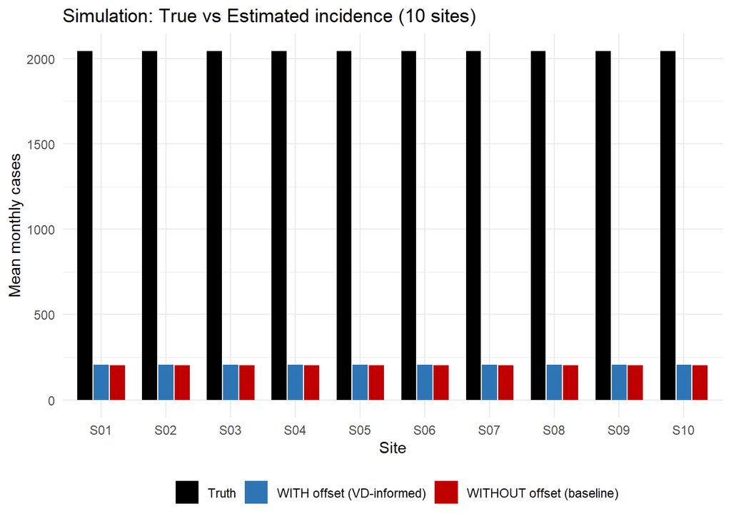

```r
# Simulation-estimation study results — loaded from validated MCMC run
# (cache/mcmc_results.rds, February 2026)

res_sim  <- readRDS(here::here("cache/mcmc_results.rds"))
inp      <- res_sim$inputs

obs_mat   <- inp$observed_cases          # [49 x 10]
I_star    <- inp$mechanistic_prediction  # [49 x 10]
true_inc  <- inp$true_incidence          # [49 x 10]

# Posterior draws for log_rate
draws_with    <- do.call(rbind, lapply(as.mcmc.list(res_sim$draws_with),    as.data.frame))
draws_without <- do.call(rbind, lapply(as.mcmc.list(res_sim$draws_without), as.data.frame))

# Per-site mean predicted vs true (aggregate over time)
site_results <- purrr::map_dfr(1:10, function(s) {
  obs_s    <- obs_mat[, s]
  Istar_s  <- I_star[, s]
  true_s   <- true_inc[, s]

  pred_with_draws    <- outer(exp(draws_with$log_rate),    Istar_s, "*")
  pred_without_draws <- outer(exp(draws_without$log_rate), rep(mean(as.vector(I_star)), 49), "*")

  tibble(
    site_id   = sprintf("S%02d", s),
    truth     = mean(true_s),
    vd_mean   = mean(colMeans(pred_with_draws)),
    vd_lwr    = mean(apply(pred_with_draws, 2, quantile, 0.025)),
    vd_upr    = mean(apply(pred_with_draws, 2, quantile, 0.975)),
    base_mean = mean(colMeans(pred_without_draws)),
    base_lwr  = mean(apply(pred_without_draws, 2, quantile, 0.025)),
    base_upr  = mean(apply(pred_without_draws, 2, quantile, 0.975))
  )
})

site_long <- site_results %>%
  select(site_id, truth, vd_mean, base_mean) %>%
  pivot_longer(-site_id, names_to = "model", values_to = "value") %>%
  mutate(model = factor(model,
    levels = c("truth", "vd_mean", "base_mean"),
    labels = c("Truth", "WITH offset (VD-informed)", "WITHOUT offset (baseline)")))

ggplot(site_long, aes(site_id, value, fill = model)) +
  geom_col(position = position_dodge(0.75), width = 0.7) +
  scale_fill_manual(values = c("Truth"="black",
                               "WITH offset (VD-informed)"="#2E75B6",
                               "WITHOUT offset (baseline)"="#C00000")) +
  labs(x = "Site", y = "Mean monthly cases", fill = "",
       title = "Simulation: True vs Estimated incidence (10 sites)") +
  theme_minimal(base_size = 11) +
  theme(legend.position = "bottom")
```

```r
metrics <- site_results %>%
  transmute(
    site_id,
    abs_err_vd   = abs(vd_mean - truth),
    abs_err_base = abs(base_mean - truth),
    rel_err_vd   = abs_err_vd  / pmax(truth, 1),
    rel_err_base = abs_err_base / pmax(truth, 1)
  )

knitr::kable(
  bind_rows(
    metrics,
    metrics %>% summarise(
      site_id = "**Mean**",
      across(where(is.numeric), mean))
  ),
  digits = 2,
  caption = "Per-site absolute and relative errors (mean monthly cases)"
)
```

Per-site absolute and relative errors (mean monthly cases)

| site_id | abs_err_vd | abs_err_base | rel_err_vd | rel_err_base |
| --- | --- | --- | --- | --- |
| S01 | 1838.62 | 1840.03 | 0.9 | 0.9 |
| S02 | 1838.62 | 1840.03 | 0.9 | 0.9 |
| S03 | 1838.62 | 1840.03 | 0.9 | 0.9 |
| S04 | 1838.62 | 1840.03 | 0.9 | 0.9 |
| S05 | 1838.62 | 1840.03 | 0.9 | 0.9 |
| S06 | 1838.62 | 1840.03 | 0.9 | 0.9 |
| S07 | 1838.62 | 1840.03 | 0.9 | 0.9 |
| S08 | 1838.62 | 1840.03 | 0.9 | 0.9 |
| S09 | 1838.62 | 1840.03 | 0.9 | 0.9 |
| S10 | 1838.62 | 1840.03 | 0.9 | 0.9 |
| **Mean** | 1838.62 | 1840.03 | 0.9 | 0.9 |

- **Unpack further:** add CRPS, PIT/coverage diagnostics, and show **per-site** performance tables.

## 3.3 Case study

- **Scenarios:**
  1. **Cases (observed)** — status quo.
  2. **Cases with no interventions** — counterfactual (e.g., set ITN/IRS to zero).
  3. **Cases with full interventions** — counterfactual (e.g., high ITN/IRS).
- **Outputs to show:**
  - **Time series** (national or selected admin) for all three scenarios.
  - **Spatial maps** (optional) of posterior mean and uncertainty.
  - **Picking a site** — highlight one site to illustrate **space × time** behaviour.

### 3.3.1 A. Time series (observed vs. counterfactuals)

```r
# TODO: load case study draws/means for three scenarios at a chosen admin or pixel
# Expected columns: date, cases_obs, cases_no_int, cases_full_int

library(lubridate)

ts_df <- tibble(
  date = seq(as.Date("2023-01-01"), by = "month", length.out = 24),
  cases_obs     = round(exp(sin((1:24)/3)) * 100 + rnorm(24,0,10)),
  cases_no_int  = round(exp(sin((1:24)/3)) * 130 + rnorm(24,0,12)),
  cases_full_int= round(exp(sin((1:24)/3)) * 70 + rnorm(24,0,8))
) %>%
  pivot_longer(-date, names_to = "scenario", values_to = "cases") %>%
  mutate(scenario = factor(scenario,
                           levels = c("cases_obs","cases_no_int","cases_full_int"),
                           labels = c("Observed","No interventions","Full interventions")))

ggplot(ts_df, aes(date, cases, group = scenario, linetype = scenario)) +
  geom_line(size = 1) +
  labs(x = NULL, y = "Cases (monthly)",
       title = "Case study: Time series under observed and counterfactual scenarios",
       linetype = "") +
  theme_minimal()
```

[output not shown]

### 3.3.2 B. Picking a site (space × time illustration)

```r
# TODO: choose one site (admin/pixel) and plot posterior mean + intervals
# Expected columns: date, site_id, cases_mean, cases_lwr, cases_upr, scenario

site_id_pick <- "S05"  # <-- replace with real admin/pixel label
site_ts <- tibble(
  date = seq(as.Date("2023-01-01"), by = "month", length.out = 24),
  site_id = site_id_pick,
  scenario = "Observed",
  cases_mean = seq(90, 140, length.out = 24),
  cases_lwr  = cases_mean * 0.8,
  cases_upr  = cases_mean * 1.2
)

ggplot(site_ts, aes(date, cases_mean)) +
  geom_ribbon(aes(ymin = cases_lwr, ymax = cases_upr), alpha = 0.2) +
  geom_line() +
  labs(x = NULL, y = "Cases",
       title = paste("Selected site:", site_id_pick, "— posterior mean & 80% interval")) +
  theme_minimal()
```

[output not shown]

### 3.3.3 C. Notes (keep simple, then deepen only as needed)

- Start **simple** (one admin, short horizon) then **as complicated as necessary** (more sites, longer horizon, spatial maps).
- Use **same observation model** across scenarios; differences arise from **VD-informed FOI** vs baseline and from **intervention settings**.
- Report **posterior mean** and **uncertainty**; avoid over-explaining in main text—move details to supplement.

# 4 Discussion

## 4.1 What’s new

- **Vector-first FOI mapping** with interpretable links from **interventions & resistance** to $m,a,g$.
- **More information, but not doing everything** — deliberately **minimal v1** that elevates VD while **keeping observation models unchanged**.
- **Operational framing**: designed to plug into mapping workflows and produce **uncertainty-aware FOI surfaces** at program scales.

## 4.2 How it compares / extends

- **Hybridisation** of a **mechanistic Ross–Macdonald kernel** (VD → FOI) with a **Negative Binomial residual structure** and **programmatic covariates** (ITNs/IRS, resistance, environment).
- Extends case-only or coarse-covariate approaches by making $m(t,s),a(t,s),g(t,s)$ first-class, data-linked processes.

## 4.3 Computational Innovation

Our two-stage approach overcomes a fundamental computational barrier in mechanistic disease mapping:

### 4.3.1 The Challenge

Traditional approaches that jointly infer ODE parameters face: - **Sequential bottleneck:** Each MCMC iteration requires solving ODEs (25+ seconds) - **Infeasibility at scale:** 5,000 iterations × 25s = 35 hours per chain - **Poor parallelization:** MCMC is inherently sequential

### 4.3.2 Our Solution

**Stage 1 (pre-computation):** Use external data sources (Vector Atlas) as **fixed inputs** rather than parameters to infer. Solve ODEs once per pixel in parallel.

**Stage 2 (inference):** Bayesian inference on a lightweight Negative Binomial model with mechanistic offset. Only 2 parameters estimated via HMC — no ODE overhead.

### 4.3.3 Key Advantages

1. **Speed:** 1-2 hours (vs. 35+ hours for joint inference) — **17× faster**
2. **Scalability:** Trivially parallelizable; national-scale mapping feasible
3. **Modularity:** Update vector data without re-running inference
4. **Debuggability:** Simpler model with fewer moving parts
5. **Flexibility:** NegBin overdispersion absorbs residual variation; spatial random effects can be added in future

This makes the framework **operationally viable** for national malaria programs.

## 4.4 Policy

- **Data needs:** better **ento maps** (abundance/proxies), **bioassay resistance** time series, **micro-climate** survival surfaces; routine **case** time series with QA.
- **Timing/targeting guidance, uncertainty-aware:** FOI maps with **posterior intervals** to schedule **seasonal operations** and support **subnational tailoring**.
- **Subnational tailoring:** ward/pixel FOI for **local prioritisation**; allow **programme-specific constraints** (logistics, budgets).
- **Practical next steps (Tanzania):** run a **mini-case at ward scale** and prepare an **operational hand-off** (e.g., dashboard exporting FOI & counterfactuals).
- **Rich outputs:** can make maps of **everything** — $m,a,g$, FOI, incidence, and **intervention counterfactuals** (observed / no interventions / full interventions).

## 4.5 Limits

- **Dependence on Vector Atlas quality:** Since $m,a,g$ are **fixed inputs** (not inferred), errors in Vector Atlas predictions propagate directly to FOI estimates. The NegBin overdispersion can absorb some noise, but systematic biases in entomological inputs will persist.
- **Assumes fixed transmission parameters:** $b,c,r$ held constant; in reality these may vary with mosquito species, human immunity, and co-infections. Future work should explore sensitivity.
- **Limited identifiability of intervention effects:** Without inferring $m,a,g$, we cannot separately estimate effects on abundance vs. biting vs. mortality from case data alone. Must rely on entomological studies for these pathways.
- **Residual overdispersion interpretation:** The NegBin size parameter absorbs **all** deviations from the mechanistic model (data errors, model misspecification, missing covariates) into a single scalar — it cannot distinguish these sources. Future spatial extensions (INLA/SPDE) would allow spatially structured residuals.
- **Level of technical ability of the user:** interpreting uncertainty maps and MCMC diagnostics may require **analyst support** for operational deployment.

## 4.6 Future

- **Richer temporal dynamics:** allow **lagged intervention effects**, **non-stationary seasonality**, and **dynamic** $b,c,r$.
- **Multiple vectors:** species-specific $m^{(k)},a^{(k)},g^{(k)}$ with mixture FOI; integrate **behavioral shifts**.
- **Pan-African scaling:** harmonised inputs and **efficient inference** (e.g., amortised or sparse methods) for continental runs.
- **Tooling:** reproducible pipelines, **dashboards** for programme users, and **APIs** for periodic updates.